# Clase 9: Georreferenciación y análisis de mapas históricos — concesiones forestales en La Araucanía (1916)

Mapeando la (In)sustentabilidad · SUS2211 · Pontificia Universidad Católica de Chile

## Objetivo

El objetivo de esta práctica es que **georreferencies un mapa histórico** — el *Plano de la reserva forestal y de las concesiones existentes en las provincias de Arauco, Malleco, Cautín y Valdivia* (1916, Ramón de Larcundo J.) — y lo uses como **fuente cartográfica primaria** para reconstruir la huella espacial de las primeras concesiones forestales en La Araucanía. Posteriormente compararás esa huella con la cobertura vegetal actual (CONAF 2017) para discutir los efectos de largo plazo de estas concesiones sobre el paisaje y los pueblos originarios.

**Herramientas por trabajar:**

- Conversión de PDF a JPG (alta resolución) para uso cartográfico
- Georreferenciación de imágenes en QGIS con sistema PSAD56 (EPSG:4248)
- Inserción de puntos de control (GCP) y validación visual con OpenStreetMap
- Digitalización de polígonos, puntos y líneas con Snapping
- Cálculo de área elipsoidal y centroides
- Matriz de distancia y unión no-espacial por tabla
- Simbología basada en reglas para la comparación con catastros vegetales

**Advertencia**

**¡Importante!** Si estás trabajando en un computador de la universidad, no olvides guardar tu trabajo en **OneDrive** (u otro servicio en la nube), de lo contrario perderás tu avance. Los computadores de la sala de clases se **borran automáticamente cada semana**.

## Resumen del trabajo de esta clase

### Capas

[output not shown]

### Procesos

1. **Pasos 1–4 — Obtención del mapa histórico.** Descargar el PDF desde la Biblioteca Nacional Digital (a `datos/brutos/`), convertirlo a JPG (alta calidad) con un servicio en línea, y guardar el JPG en `datos/intermedios/` (la conversión es un paso humano, no es dato bruto).
2. **Pasos 5–11 — Georreferenciación.** Configurar el Georreferenciador con sistema **PSAD56 (EPSG:4248)**, insertar al menos **6 puntos de control (GCP)** sobre intersecciones de latitud y longitud visibles en el mapa, ejecutar la transformación lineal y guardar tanto el ráster georreferenciado como los puntos de control para reproducibilidad.
3. **Pasos 12–18 — Digitalización.** Crear shapefiles para tres geometrías: **polígonos** de concesiones forestales, **puntos** para Temuco y Valdivia, y una **línea** para la vía principal que conecta ambas ciudades. Activar **Snapping** para garantizar precisión geométrica.
4. **Pasos 19–24 — Análisis espacial.** Calcular **área elipsoidal**, **centroides**, **matriz de distancia** entre cada concesión y las dos ciudades, y construir un **mapa de cercanía** (concesiones coloreadas según distancia mínima a la ciudad más próxima).
5. **Pasos 25–28 — Comparación con CONAF 2017.** Superponer el catastro vegetacional actual sobre las concesiones de 1916, simbolizar por reglas (Bosques / Terrenos agrícolas / Otros) y producir el mapa final — la **huella histórica** sobre el paisaje contemporáneo.

## Preparación: descarga y organización del material

### Descarga desde Canvas

**1.** Descarga el archivo `.zip` de esta tarea desde la página del curso en **Canvas** (carpeta “Clase 9”). El archivo contiene la capa de la Región de La Araucanía y el catastro vegetacional 2017 ya organizados.

**2.** Descomprime el archivo en una ubicación dedicada a este curso. Algunas opciones:

- **Computador personal:** descomprime dentro de tu carpeta `SUS2211/`.
- **Computador de la sala:** descomprime en el escritorio o en Documentos, pero **antes de terminar la sesión**, copia toda la carpeta a OneDrive, un pendrive u otro servicio en la nube.

### Estructura de carpetas del proyecto

Al descomprimir el archivo, encontrarás la siguiente estructura de carpetas. Esta organización es la misma que hemos usado en clases anteriores y es **estándar para todas las tareas del curso**.

```
flowchart TD
    A["📁 clase9/"] --> B["📁 datos/"]
    A --> C["📁 documentos/"]
    A --> D["📁 proyectos/"]
    A --> E["📁 resultados/"]

    B --> F["📁 brutos/<br>🔒 datos originales<br>(no modificar)"]
    B --> G["📁 intermedios/<br>datos de geoprocesamiento"]
    B --> H["📁 procesados/<br>capas finales para mapeo"]

    E --> I["📁 mapas/<br>mapas exportados"]
    E --> J["📁 figuras/<br>gráficos y tablas"]

    style F fill:#fde8e8,stroke:#c0392b
    style G fill:#fef9e7,stroke:#f39c12
    style H fill:#eafaf1,stroke:#27ae60
    style D fill:#eaf4fb,stroke:#2980b9
    style C fill:#f4f6f7,stroke:#7f8c8d
```

**Tip¿Para qué sirve cada carpeta?**

**`datos/`** — Todo lo relacionado con los datos geoespaciales, organizado en tres subcarpetas:

**`documentos/`** — Documentación de respaldo. Se recomienda incluir una bitácora (`bitacora.txt` o `pasos.md`) que describa cómo transformaste los datos y, en particular, **qué intersecciones de latitud y longitud usaste como puntos de control**.

**`proyectos/`** — Archivos de proyecto QGIS (`.qgz`). Guarda aquí el proyecto de esta tarea, nómbralo `clase9.qgz`.

**`resultados/`** — Productos finales:

- **`mapas/`** Los dos mapas finales: el **mapa de cercanía** (concesiones por distancia a ciudades) y el **mapa de huella** (concesiones de 1916 sobre el catastro 2017), exportados a PDF o imagen.
- **`figuras/`** Gráficos, tablas u otros outputs.

### Material descargado

Dentro de `datos/brutos/` encontrarás los siguientes archivos:

| Archivo | Descripción |
| --- | --- |
| `Region_Araucania` (.gpkg) | Polígono del límite de la Región de La Araucanía. |
| `Catastro_Vegetacional_2017` (.gpkg) | Catastro vegetacional CONAF 2017 con atributo `USO` (tipo de cobertura). |

**Tip**

**El mapa histórico lo obtendrás tú.** En esta tarea el primer ejercicio consiste en **buscar y descargar** la cartografía original desde la Biblioteca Nacional Digital de Chile — un repositorio público y gratuito de patrimonio cultural. Aprender a obtener material primario es parte central de la práctica.

## Paso 1 | Crear el proyecto y activar el mapa base

**1.** Inicia QGIS en el computador.

**2.** Crea un proyecto nuevo y guárdalo dentro de la carpeta `proyectos/` con el nombre `clase9.qgz` (recuerda guardarlo en **OneDrive** si trabajas desde un computador de la sala).

[figure not shown]

Crear un proyecto nuevo en QGIS.

**3.** Como ya lo hemos hecho en clases anteriores, activa un **mapa base** OpenStreetMap para tener una referencia visual. Ve a: **Web → QuickMapServices → OSM → OSM Standard**.

## Paso 2 | Descargar el mapa histórico desde la Biblioteca Nacional Digital

**Tip**

**¿Por qué la Biblioteca Nacional Digital?** Es el repositorio público y gratuito de patrimonio cultural de Chile, e incluye una **Mapoteca** con cartografía histórica digitalizada. Aprender a obtener material primario desde fuentes oficiales es una habilidad clave: te permite trabajar con datos verificables y citables, en lugar de depender de copias de terceros sin procedencia clara.

**4.** Abre tu navegador y entra a la **Biblioteca Nacional Digital de Chile** (https://www.bibliotecanacionaldigital.gob.cl).

[figure not shown]

Página principal de la Biblioteca Nacional Digital de Chile.

**5.** En el buscador, escribe: **“Plano de la reserva forestal y de las concesiones existentes en las provincias de Arauco, Malleco, Cautín y Valdivia”**, o filtra por **Mapoteca** y busca a **Ramón de Larcundo J.** (autor, 1916).

**6.** Una vez en la ficha del mapa, haz click en **Visualizar** y descarga el archivo en formato **PDF**. Guarda el archivo dentro de `datos/brutos/` con el nombre `Plano_1916.pdf`.

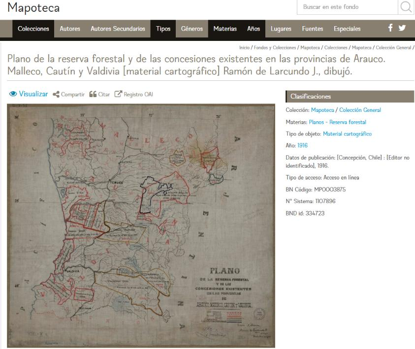

Ficha del *Plano de la reserva forestal* (1916) en la Mapoteca de la Biblioteca Nacional Digital. Click en Visualizar para descargar.

## Paso 3 | Convertir el PDF a JPG en alta resolución

**Tip**

**¿Por qué convertir a JPG?** El Georreferenciador de QGIS trabaja con formatos ráster (JPG, TIF, PNG), no con PDF. Necesitamos extraer la **imagen** del PDF para poder cargarla como ráster, asignarle puntos de control y proyectarla.

**7.** Abre un convertidor en línea de PDF a JPG, por ejemplo **iLovePDF** (https://www.ilovepdf.com/es/pdf_a_jpg).

**8.** Sube el archivo `Plano_1916.pdf`. En la columna derecha:

- **Modo:** “Páginas a JPG” (cada página del PDF se convierte en una imagen JPG)
- **Calidad de imagen:** **Alta** (¡muy importante! la opción “Normal” pierde detalle del mapa histórico)

Haz click en **Convertir a JPG** y descarga el resultado.

[figure not shown]

Configuración de iLovePDF: páginas a JPG con calidad Alta.

**9.** Guarda el archivo resultante dentro de `datos/intermedios/` con el nombre `Plano_1916.jpg`.

**Tip**

**¿Por qué `intermedios/` y no `brutos/`?** Aunque el JPG sale del PDF original, **tú elegiste el formato (JPG vs. TIF), la calidad (“Alta” vs. “Normal”) y la herramienta de conversión** (iLovePDF). Eso es una decisión humana sobre los datos, no una descarga directa: por convención, los archivos transformados — incluso ligeramente — viven en `intermedios/`, mientras que `brutos/` queda **intacto**. Así, si en el futuro alguien quiere reproducir tu trabajo desde cero, sabe exactamente desde dónde partir.

**Advertencia**

**Antes de continuar:** abre el JPG con un visor de imágenes y verifica que se ve nítido — debes poder leer los nombres de las concesiones, los números de hectáreas y, sobre todo, las **marcas de latitud y longitud en los bordes del mapa**. Si la imagen se ve borrosa, vuelve al paso 8 y conviértela de nuevo seleccionando “Alta” en calidad de imagen.

## Paso 4 | Abrir el Georreferenciador en QGIS

**10.** Vuelve a QGIS y abre el **Georreferenciador**: ve al menú superior **Capa → Georreferenciador…**

[figure not shown]

Acceso al Georreferenciador desde el menú Capa.

**11.** Se abrirá una ventana vacía con una barra de herramientas y una **Tabla de PCT** (Puntos de Control Terrestre) en la parte inferior. Esta es la herramienta donde definiremos la referencia espacial del mapa histórico.

[figure not shown]

Ventana del Georreferenciador con la Tabla de PCT vacía.

## Paso 5 | Configurar la transformación con sistema PSAD56

**Tip**

**¿Qué es PSAD56?** Es un **datum sudamericano** (Provisional South American Datum 1956) usado ampliamente en la cartografía chilena de mediados del siglo XX. Para mapas históricos como el de 1916, PSAD56 entrega una proyección **mucho más fiel** que sistemas modernos como WGS84 o SIRGAS2000, evitando errores de desplazamiento. El código EPSG correspondiente es **4248** (también puede aparecer como **4723** en algunas versiones).

**12.** En la ventana del Georreferenciador, ve a **Configuración → Configurar transformación…**

**13.** Configura los parámetros:

- **Tipo de transformación:** Lineal
- **Target CRS (SRC objetivo):** haz click en el ícono y busca `PSAD56`
- Selecciona **EPSG:4248 — PSAD56**

Click en **Aceptar**.

[figure not shown]

Selección del SRC PSAD56 (EPSG:4248) como sistema objetivo de la transformación.

## Paso 6 | Cargar la imagen JPG del mapa histórico

**14.** En el Georreferenciador, ve a **Archivo → Abrir ráster…** (también disponible como ícono en la barra de herramientas).

**15.** Selecciona el archivo `Plano_1916.jpg` que guardaste en `datos/intermedios/` y ábrelo.

[figure not shown]

**Nota**

**PAUSA** — la imagen del mapa histórico aparecerá en el panel principal del Georreferenciador. Tómate unos minutos para **explorarla**: identifica los bordes del mapa, las marcas de latitud y longitud (en grados), las dos ciudades grandes (Temuco y Valdivia) y los polígonos rojos que delimitan las concesiones forestales.

## Paso 7 | Insertar los puntos de control (GCP)

**Tip**

**¿Qué es un GCP?** Un **Punto de Control Terrestre** (Ground Control Point) asocia un punto de la imagen a sus coordenadas geográficas reales. Mientras más GCPs insertes — y mejor distribuidos por la imagen — más precisa será la georreferenciación.

En este mapa tenemos una ventaja: **los bordes del mapa muestran latitud y longitud explícitas**. Vamos a usar las **intersecciones entre líneas de latitud y longitud** como puntos de referencia.

**16.** Activa el ícono **“Añadir punto”** (la chinche con un signo +) en la barra del Georreferenciador.

**17.** Haz click sobre una **intersección** entre una línea de latitud y una de longitud visible en el mapa (por ejemplo, donde la línea de **38° S** se cruza con la de **73° W**).

**18.** Se abrirá una ventana **“Introducir coordenadas de mapa”**. Ingresa las coordenadas correspondientes:

- **X / Este:** la longitud en grados decimales (al **oeste** de Greenwich → **negativa**, ej. `-73`)
- **Y / Norte:** la latitud en grados decimales (en el **hemisferio sur** → **negativa**, ej. `-38`)

Haz click en **Aceptar**.

[figure not shown]

Diálogo para introducir las coordenadas X (longitud) e Y (latitud) del punto de control.

**Advertencia**

**OJO con los signos.** Es el error más común al georreferenciar Chile:

- La **latitud sur es negativa** (Chile continental: aprox. `-17` a `-56`).
- La **longitud al oeste de Greenwich es negativa** (Chile continental: aprox. `-66` a `-76`).

Si confundes los signos, el mapa se proyectará en el lugar equivocado del planeta y pensarás que “no funcionó”. Antes de aceptar cada GCP, verifica el signo.

**Tip**

**Para tu próxima georreferenciación: cuidado con los minutos.** El mapa de 1916 que estamos usando aquí marca la cuadrícula **solo en grados enteros**, así que puedes ingresar los GCPs directamente (`-38`, `-73`, etc.). Pero **muchos otros mapas históricos** marcan la cuadrícula con mayor detalle, en intervalos de **minutos** (por ejemplo, líneas cada 30’ o 15’). En esos casos, antes de ingresar cada coordenada, debes convertir los minutos a **grados decimales**, porque QGIS no acepta el formato grados-minutos-segundos.

Los **minutos están en base 60**, así que para convertirlos divides por 60:

- `37° 30'` → 37 + 30/60 = **37.5**
- `38° 15'` → 38 + 15/60 = **38.25**
- `73° 45'` → 73 + 45/60 = **73.75**

Y recuerda **aplicar el signo al final**: una latitud de `38° 30' S` se ingresa como **`-38.5`**, y una longitud de `73° 15' W` como **`-73.25`**.

**19.** Repite el proceso para insertar **al menos 6 puntos de control**, distribuidos por todo el mapa (esquinas + algunos puntos intermedios). Mientras más puntos y mejor distribuidos, mayor precisión.

[figure not shown]

Mapa histórico con 6 puntos de control insertados y la Tabla de PCT con sus coordenadas y residuos.

**Tip**

**Lectura de residuales.** En la columna **“Residual (píxeles)”** de la Tabla de PCT, valores **bajos** (idealmente menores a la mitad del lado de la imagen en píxeles dividido por el número de GCPs) indican un buen ajuste. Si un punto tiene un residual mucho más alto que el resto, probablemente lo insertaste mal o invertiste un signo — bórralo y vuelve a intentar.

## Paso 8 | Ejecutar la georreferenciación

**20.** Antes de ejecutar, vuelve a **Configuración → Configurar transformación** y completa el campo **“Output file”**:

- Click en los puntos suspensivos
- Navega a `datos/intermedios/` y nombra el archivo `Plano_1916_georef.tif`
- Marca **“Load in project when done”** para que la imagen se cargue automáticamente al proyecto principal

[figure not shown]

**21.** Haz click en **Aceptar**, luego presiona el botón **“Comenzar georreferenciado”** (la flecha verde en la barra de herramientas) para ejecutar el proceso.

[figure not shown]

Botón Comenzar georreferenciado en la barra del Georreferenciador.

## Paso 9 | Guardar los puntos de control para reproducibilidad

**Tip**

**¿Por qué guardar los GCPs?** Si en el futuro quieres re-georreferenciar este mismo mapa (con más puntos, otra transformación, otra persona del equipo), no querrás volver a hacer click en cada intersección. Guardar el archivo `.points` te permite **cargar los GCPs de nuevo** en el Georreferenciador en otra sesión.

**22.** En el Georreferenciador, haz click en el ícono **“Guardar puntos de control como…”**.

**23.** Guárdalo dentro de `datos/intermedios/` con el nombre `Plano_1916.points`.

[figure not shown]

## Paso 10 | Verificar la georreferenciación con OpenStreetMap

**24.** Cierra el Georreferenciador. La imagen `Plano_1916_georef.tif` debería estar cargada en el proyecto principal de QGIS, **alineada sobre el mapa base OSM**.

**25.** Verifica visualmente que el mapa histórico **calza con la geografía actual**: los ríos del 1916 deberían aproximarse a los actuales, los grandes asentamientos (Temuco, Valdivia) deberían quedar cerca de las ciudades modernas.

[figure not shown]

Mapa histórico georreferenciado proyectado sobre el mapa base OSM. El mapa debe alinearse correctamente con la geografía actual.

**Nota**

**Resultado esperado:** el mapa histórico **se posa sobre el OSM** sin desplazamientos evidentes. Si el ajuste es malo (la imagen aparece torcida, o desplazada en kilómetros), vuelve al paso 7 y revisa los signos de tus GCPs y la distribución espacial de los puntos.

## Paso 11 | Cargar el límite de la Región de La Araucanía

**26.** Ve a **Capa → Añadir capa → Añadir capa vectorial…** y carga `datos/brutos/Region_Araucania.gpkg`.

[figure not shown]

Mapa histórico georreferenciado con el límite regional de La Araucanía superpuesto.

**27.** Configura el estilo de la capa para que **veas a través** y puedas trabajar las concesiones que están dentro: doble click sobre la capa → **Simbología → Relleno → Estilo de relleno → “Sin relleno”**. Mantén el contorno (color rojo, ancho ~0.6 mm).

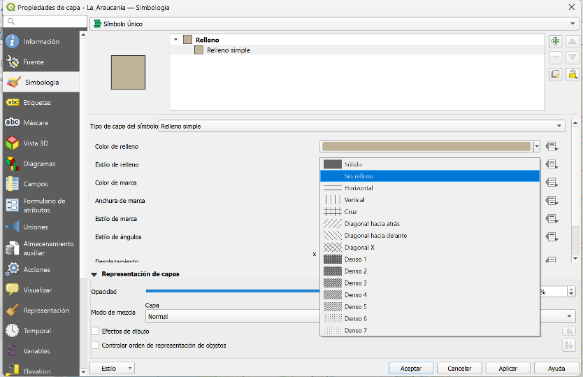

Configurar el límite regional con relleno transparente para ver las concesiones por debajo.

## Paso 12 | Crear la capa de Concesiones Forestales (polígono)

**Tip**

**¿Qué vamos a digitalizar?** Vamos a crear **tres capas vectoriales nuevas**, dibujando manualmente sobre el mapa histórico:

1. **Concesiones Forestales** (polígonos) — los polígonos rojos que aparecen en el mapa de 1916
2. **Ciudades** (puntos) — Temuco y Valdivia, los dos asentamientos visibles
3. **Camino** (línea) — la vía principal que conecta ambas ciudades

Para cada concesión, además de dibujar el polígono, registraremos sus atributos: **nombre, decreto, estado (existente o caducada), año del decreto y hectáreas declaradas en la cartografía**.

**28.** Para empezar la digitalización de Concesiones Forestales, crea un Shapefile. Ve a **Capa → Crear capa → Nueva capa de archivo shape…**

[figure not shown]

Menú Capa > Crear capa > Nueva capa de archivo shape.

**29.** Configura los parámetros básicos:

- **Nombre de archivo:** `datos/intermedios/Concesiones_Forestales.shp`
- **Codificación de archivo:** UTF-8
- **Tipo de geometría:** **Polígono**
- **SRC:** **EPSG:4248 — PSAD56** (el mismo que usamos al georreferenciar)

[figure not shown]

Configuración inicial de la capa Concesiones_Forestales: polígono, EPSG:4248 PSAD56.

**30.** En la sección **“Nuevo campo”**, agrega los siguientes campos uno por uno (presiona **“Añadir a la lista de campos”** después de cada uno):

| Nombre | Tipo | Longitud |
| --- | --- | --- |
| `Nombre` | Texto (cadena) | 80 |
| `Decreto` | Entero (32 bit) | 10 |
| `Estado` | Texto (cadena) | 20 |
| `Hectareas` | Entero (32 bit) | 10 |
| `Anodecreto` | Entero (32 bit) | 10 |

Una vez completa la lista, click en **Aceptar**.

[figure not shown]

Lista de campos: Nombre, Decreto, Estado, Hectareas, Anodecreto.

## Paso 13 | Activar y configurar Snapping

**Tip**

**¿Qué es el Snapping?** El **Snapping** garantiza que los vértices y bordes de los polígonos, puntos o líneas que dibujes se **ajusten con precisión** a otros elementos geográficos del mapa, evitando huecos o superposiciones invisibles. Es esencial para que la **vía principal** se conecte correctamente con las **ciudades**, y para que las concesiones que comparten un límite calcen perfectamente.

**31.** Ve a **Proyecto → Opciones de autoensamblado…**

[figure not shown]

Acceder a Opciones de autoensamblado desde el menú Proyecto.

**32.** Configura:

- Activa **Snapping** (ícono del imán en la barra superior)
- **Tipo de ajuste:** Vértice y segmento
- **Tolerancia:** 10 píxeles
- **Unidades:** píxeles
- *(Opcional pero recomendado)* Activa **“Autoensamblado en intersecciones”**

[figure not shown]

Barra de configuración de autoensamblado con Vértice + Segmento, 10 píxeles.

## Paso 14 | Digitalizar las concesiones forestales

**33.** Selecciona la capa `Concesiones_Forestales` en el panel **Capas** y activa el modo **edición** (ícono del lápiz amarillo). Luego haz click en **“Añadir polígono”**.

[figure not shown]

Barra de herramientas de edición: lápiz (modo edición) y polígono (añadir polígono).

**34.** Comienza a dibujar **una concesión a la vez**, siguiendo el contorno rojo de cada polígono visible en el mapa histórico. Usa referencias visibles (ríos, caminos, límites territoriales) para delimitar cada polígono. Click izquierdo para añadir vértices; click derecho para cerrar el polígono.

**35.** Al cerrar cada polígono, se abrirá una ventana emergente para llenar los **atributos**. Lee los datos directamente desde la cartografía:

- **`Nombre`** — el nombre de la concesión (ej. *Bara Erans*, *Nueva Italia*, *Quepe*, etc.)
- **`Decreto`** — el número de decreto (ej. `352`)
- **`Estado`** — `Existente` o `Caducada` (suele estar indicado en la leyenda de cada polígono)
- **`Hectareas`** — las hectáreas declaradas (ej. `21750`)
- **`Anodecreto`** — el año del decreto (puede coincidir con 1916 o ser anterior)

[figure not shown]

Ventana emergente al cerrar un polígono: atributos Nombre, Decreto, Estado, Hectareas, Anodecreto.

**36.** Repite el proceso para **todas las concesiones** dentro del polígono regional. Una vez terminado, **guarda los cambios** (ícono del disquete) y desactiva la edición.

[figure not shown]

Mapa con todas las concesiones forestales digitalizadas como polígonos amarillos.

## Paso 15 | Crear la capa de Ciudades (punto)

**37.** Repite el procedimiento del paso 12, pero con:

- **Nombre de archivo:** `datos/intermedios/Ciudades.shp`
- **Tipo de geometría:** **Punto**
- **SRC:** **EPSG:4248 — PSAD56**
- **Campos:**

| Nombre | Tipo | Longitud |
| --- | --- | --- |
| `Ciudad` | Texto (cadena) | 80 |

[figure not shown]

Configuración de la capa Ciudades: punto, PSAD56, campo Ciudad.

**38.** Activa la edición y digitaliza **dos puntos**: uno sobre **Temuco** y otro sobre **Valdivia** (ambos visibles en el mapa histórico). En la ventana emergente, llena el campo `Ciudad` con el nombre correspondiente.

[figure not shown]

Mapa con las concesiones forestales y los dos puntos de ciudades (Temuco al norte, Valdivia al sur).

## Paso 16 | Crear la capa de Camino (línea)

**39.** Repite el procedimiento, pero con:

- **Nombre de archivo:** `datos/intermedios/Camino.shp`
- **Tipo de geometría:** **Línea**
- **SRC:** **EPSG:4248 — PSAD56**

**40.** Activa la edición y dibuja la **vía principal** que conecta Temuco con Valdivia (visible en el mapa histórico, generalmente como una línea con pequeñas marcas perpendiculares). Aprovecha el **Snapping** para que los extremos de la línea se peguen exactamente a los puntos de las dos ciudades.

**Nota**

**PAUSA** — al terminar este paso deberías tener tres capas digitalizadas. Apaga temporalmente la imagen del mapa histórico (desactivando la casilla de la capa `Plano_1916_georef`) para ver tus elementos sobre el mapa base OSM:

[figure not shown]

Las tres capas digitalizadas (concesiones, ciudades y camino) sobre el mapa histórico.

[figure not shown]

Las mismas capas con la imagen histórica desactivada — sobre el mapa base OSM.

## Paso 17 | Calcular el área elipsoidal de cada concesión

**Tip**

**¿Por qué área elipsoidal?** Cuando trabajamos con coordenadas geográficas (grados de latitud/longitud), las **áreas planas** salen distorsionadas: en latitudes altas un grado mide menos kilómetros que en el ecuador. El **cálculo elipsoidal** corrige esa distorsión proyectando los polígonos sobre un modelo elipsoidal de la Tierra y entrega áreas en **metros cuadrados reales**.

**41.** Ve a **Vectorial → Herramientas de geometría → Agregar atributos de geometría…**

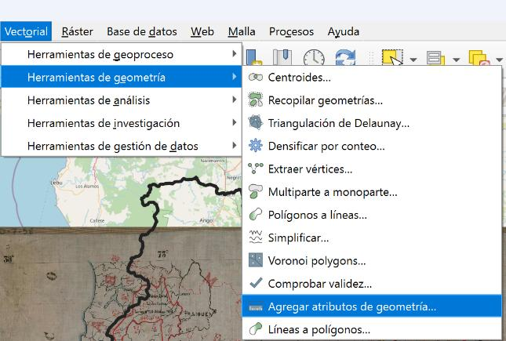

Menú Vectorial > Herramientas de geometría > Agregar atributos de geometría.

**42.** Configura:

- **Capa de entrada:** `Concesiones_Forestales`
- **Calcular usando:** **Elipsoidal**

[figure not shown]

Configuración del algoritmo Agregar atributos de geometría con cálculo Elipsoidal.

**43.** *(Opcional pero recomendado)* En **Avanzado**, abre la caja de opciones y selecciona **“Do not filter (Better Performance)”** en *Invalid feature filtering*. Así, todos los polígonos serán evaluados aunque tengan formas irregulares.

[figure not shown]

Opciones avanzadas: Do not filter (Better Performance).

**44.** Click en **Ejecutar**. Se generará una nueva capa temporal con los campos `area` y `perimeter`. Verifica abriendo su tabla de atributos: los **primeros 4 dígitos** del campo `area` deberían coincidir aproximadamente con las hectáreas que registraste en `Hectareas` (1 ha ≈ 10.000 m²).

[figure not shown]

Tabla de atributos con `area` calculada — los primeros dígitos coinciden con las hectáreas declaradas en la cartografía.

**Tip**

**Diferencia esperada.** Es **normal** que el área calculada y las hectáreas declaradas no calcen exactamente. La diferencia es **atribuible a la imprecisión de las técnicas topográficas de comienzos del siglo XX** que, aunque impresionantes para su época, distan de la precisión que se puede lograr con SIG modernos. Es un buen recordatorio de que **toda cartografía está mediada por su tecnología de producción**.